# Exploring the BRFSS data

## Setup

### Load packages

```r
library(ggplot2)
library(dplyr)
```

### Load data

```r
load("brfss2013.RData")
```

## Part 1: Data

About random sampling:

1. In landline telephone survey, interviewers collect data from a randomly selected adult in a household. Since an adult is randomly selected from the household, the subject is representative of all adults in that household, and any conclusion drawn based on that subject can be generalized to that specific household as well. However, the documentation does not mention about how the “household” has been selected, maybe it’s not at random. Since the survey is not mandatory, the sample households are only those who are willing to cooperate with the interviewers, so the sample must be somewhat biased, and the conclusion cannot generalize well to the whole population.
2. In the cellular telephone version survey, interviewers collect data from an adult who participates by using a cellular telephone and resides in a private residence or college housing. Again, this is not random sampling at large, any conclusion can only be generalized to the participants who resides in a private residence or college housing.

About random assignment:

1. Overall, the dataset comes from a broad survey that spans over states for more than 30 years. There’s no experiments being conducted, no control groups, but it’s just a survey that collects data from households based on some questionnaires.
2. In order to make conclusions about a causal relationship, we need to control the potential confounders and focus on the explanatory variables and response variables specific to our problems. Since there are more than 300 variables, the data varies greatly in diversity, and it’s really hard if we want to choose a subset of the data and keep other variables unchanged. Some rigorous data cleaning task must be performed before we can analyse it in a meaningful manner. Therefore, any conclusions should refer to only correlation between variables rather than causal relationship.

## Part 2: Research questions

**Research quesion 1:**

Smoking is usually said to be the most detrimental to peoples’ health. How many males and females are everyday regular smokers? Do regular smokers in general have worse health status?

**Research quesion 2:**

In general, most pregnant women cares a lot about their health status more than others. They tend to exercise everyday, eat healthy food, get enough sleep in order for their babies to be healthy. I wonder if this is true. Are pregnant women in general more healthy than others? How likely are they going to drink alcohols?

**Research quesion 3:**

Is there a difference in incomes between males and females if they have the same education level? What does the distribution looks like? For simplicity, I’m going to analyse this question on a subset of the data where both males and females are college graduates.

## Part 3: Exploratory data analysis

**Research quesion 1:**

Smoking is usually said to be the most detrimental to peoples’ health. How many males and females are everyday regular smokers? Do regular smokers in general have worse health status?

As per the document, “smokday2” variable refers to the smoking frequency. First, the filter function select all regular smokers data, and then pass it to ggplot() that draws a barplot with “sex” on the horizontal axis.

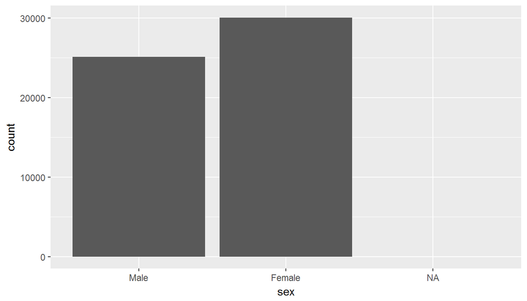

```r
brfss2013 %>%
  filter(smokday2 == "Every day") %>%
  ggplot(aes(x = sex)) + geom_bar()
```

The graph indicates that there are around 25,000 male regular smokers among the participants, and slightly over 30,000 female regular smokers.

To see if regular smokers are healthy or not, draw a barplot with “genhlth” - general health status on the x-axis.

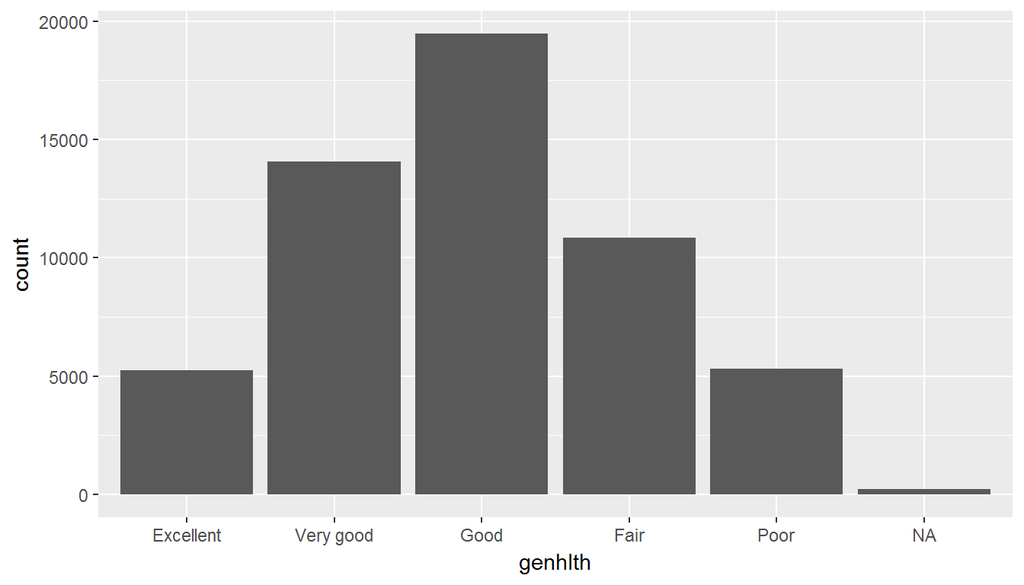

```r
brfss2013 %>%
  filter(smokday2 == "Every day") %>%
  ggplot(aes(x = genhlth)) + geom_bar()
```

As we can see, only a small part of regular smokers are suffering from poor health conditions. It looks like regular smokers are not necessarily unhealthy in general, but we cannot say anything other than this. To decide if smoking makes one unhealthy, other factors such as how long one has smoked and the subject’s age should also be in consideration.

**Research quesion 2:**

In general, most pregnant women cares a lot about their health status more than others. They tend to exercise everyday, eat healthy food, get enough sleep in order for their babies to be healthy. I wonder if this is true. Are pregnant women in general more healthy than others? How likely are they going to drink alcohols?

Using the fill argument within the ggplot() function, we can draw a barplot showing the distribution of general health status, with pregnant data inside the bar.

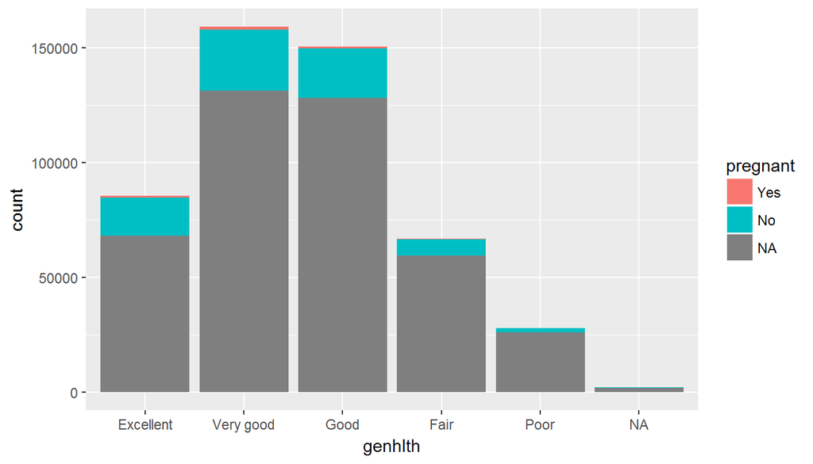

```r
brfss2013 %>%
  ggplot(aes(x = genhlth, fill = pregnant)) + geom_bar()
```

Even if pregnant participants are rare in the sample, we can still see that almost all of them are in relatively good shape.

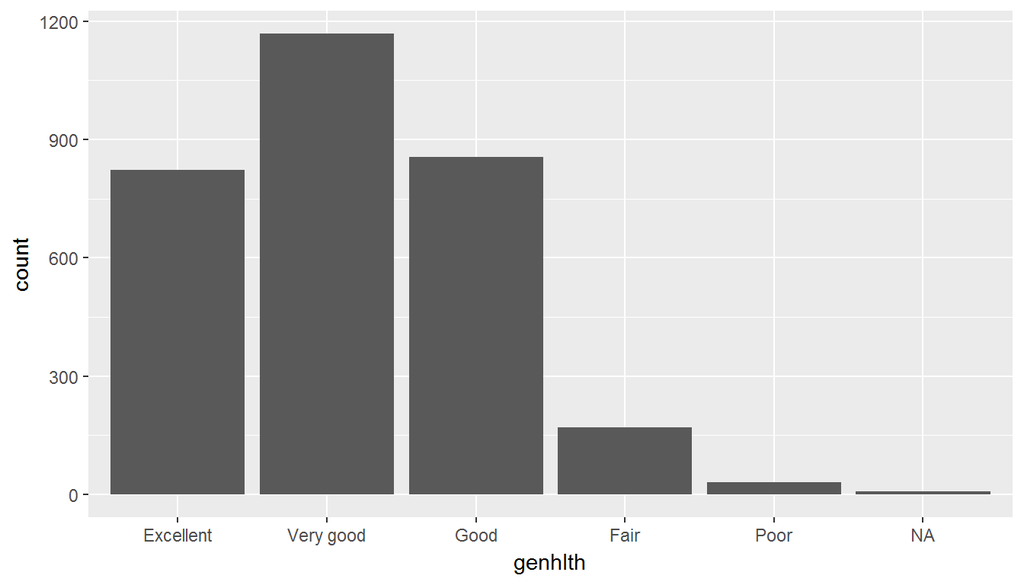

```r
brfss2013 %>%
  filter(pregnant == "Yes") %>%
  ggplot(aes(x = genhlth)) + geom_bar()
```

To further confirm the point, now this graph clearly suggests that pregnant women who are in bad fair or poor health status are very rare, and they are in fact more healthy than the whole population.

To see how much alcohol pregnant women tend to drink, the summarise function create a new variable called “avg_alcohol”, which is calculated as the median of “alcday5”. “alcday5” refers to the coded frequency of drinking alcohols, because we don’t have any numerical data here, we use median() rather than mean(). Then the arrange(desc()) outputs “avg_alcohol” grouped by “pregnant”.

```r
brfss2013 %>%
  group_by(pregnant) %>%
  summarise(avg_alcohol = median(alcday5, na.rm = TRUE)) %>%
  arrange(desc(avg_alcohol))
```

```
## # A tibble: 3 x 2
##   pregnant avg_alcohol
##   <fct>          <int>
## 1 No               101
## 2 Yes                0
## 3 <NA>               0
```

As a result, the median indicates that most pregnant women do not drink at all. On the flip side, non-pregnant subjects have a median of “101”, which means that non-pregnant people on average drink at least one alcohol per week.

**Research quesion 3:**

Is there a difference in incomes between males and females if they have the same education level? What does the distribution looks like? For simplicity, I’m going to analyse this question on a subset of the data where both males and females are college graduates.

We first filter the data on only college graduates. Then create the barplot showing the income level on males and females.

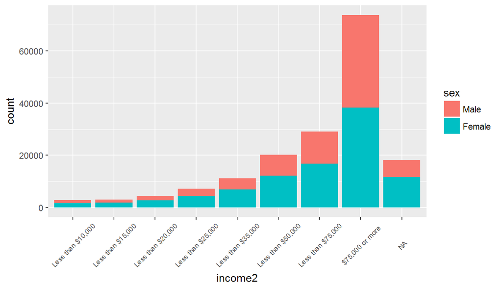

```r
brfss2013 %>%
  filter(educa == "College 4 years or more (College graduate)") %>%
  ggplot(aes(x = income2, fill = sex)) + geom_bar() +
  theme(axis.text.x = element_text(size = 7, angle = 45, hjust = 0.5, vjust = 0.5))
```